# Homework4_SDS315

Caroline Zhuang

[output not shown]

# **Problem 1**

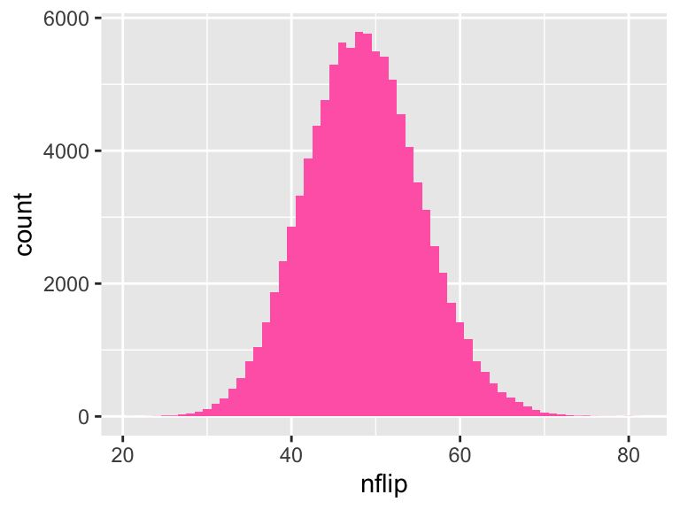

```
## [1] 0.0018
```

In this problem, the null hypothesis that we are testing is if security trades at Iron Bank are flagged at the same 2.4% baseline rate as others. In this scenario, the test statistic is the 70 flagged out of the last 2021 trades at Iron Bank. Since the p-value, 0.0018, is rather small, I think the null hypothesis may not be completely plausible. This might mean that the baseline rate at Iron Bank is higher than others.

# **Problem 2**

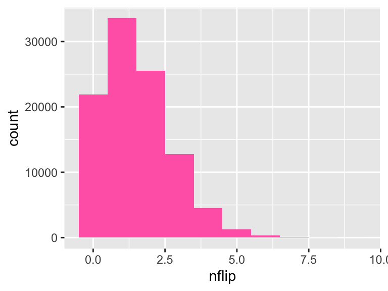

```
## [1] 0.00012
```

# **Problem 3**

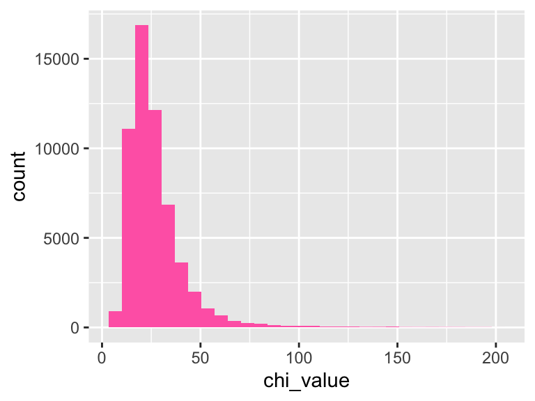

```
## [1] 26.95035
```

```
## # A tibble: 10 × 2
##    sentence                                                              p_value
##    <chr>                                                                   <dbl>
##  1 She opened the book and started to read the first chapter, eagerly a…   0.513
##  2 Despite the heavy rain, they decided to go for a long walk in the pa…   0.926
##  3 The museum’s new exhibit features ancient artifacts from various civ…   0.076
##  4 He carefully examined the document, looking for any clues that might…   0.489
##  5 The students gathered in the auditorium to listen to the guest speak…   0.484
##  6 Feeling vexed after an arduous and zany day at work, she hoped for a…   0.009
##  7 The chef demonstrated how to prepare a delicious meal using only loc…   0.328
##  8 They watched the sunset from the hilltop, marveling at the beautiful…   0.988
##  9 The committee reviewed the proposal and provided many points of usef…   0.084
## 10 Despite the challenges faced during the project, the team worked tir…   0.059
```

The sentence that is produced by LLM is sentence #6. This is because the p-value for sentence 6 is very low compared to the other sentences, meaning the probability that the null-hypothesis (in this case, chi-squared values for letter frequencies) is probably false, which means the distribution of letters is different than what is usually seen.